# STA207 Hw2 - Eric Kalosa-Kenyon

```r
library("additivityTests")
library("gplots")
library("plyr")
```

# 21.7

## 21.7.a

Age is used as a blocking variable because age is a highly relevant metabolic covariate. That is, peoples’ metabolisms slow as they age.

## 21.7.b

```r
# Load data
fat = c(.73, .86, .94, 1.40, 1.62,
        .67, .75, .81, 1.32, 1.41,
        .15, .21, .26, .75, .78)
df = data.frame(fat)
age = c()
diet = c()
for (i in 1:length(fat)){
    age = c(age, ((i - 1) %% 5) + 1)
    diet = c(diet, ceiling(i / 5))
}
df$age = as.factor(age)
df$diet = as.factor(diet)

aov_fat = with(df, aov(fat ~ diet + age))
anova(aov_fat)
```

```
## Analysis of Variance Table
##
## Response: fat
##           Df  Sum Sq Mean Sq F value    Pr(>F)
## diet       2 1.32028 0.66014  273.35 4.326e-08 ***
## age        4 1.41896 0.35474  146.89 1.610e-07 ***
## Residuals  8 0.01932 0.00242
## ---
## Signif. codes:  0 '***' 0.001 '**' 0.01 '*' 0.05 '.' 0.1 ' ' 1
```

We see that both age and diet are significant drivers of lipid content.

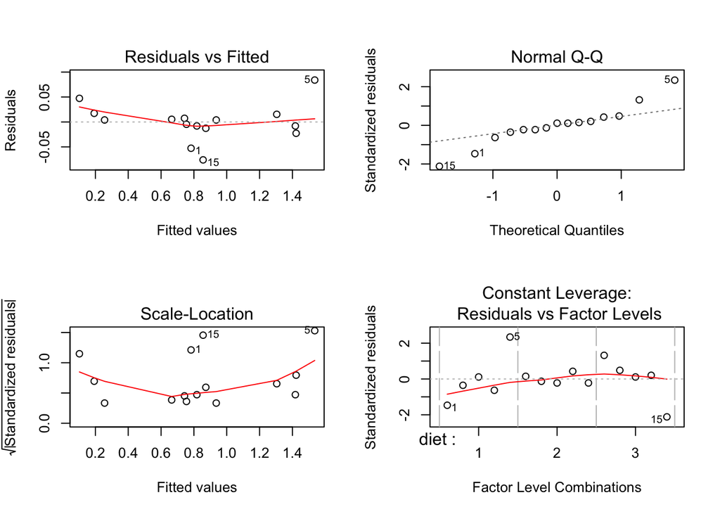

```r
par(mfrow=c(2,2))
plot(aov_fat)
```

Notice that the residuals are not normal and heteroskedastic. We interpret the difference between the emperical to theoretical quantiles in the QQ plot to entail the invalidity of the normality asumption. We interpret the non-horizontal red line in the residuals plot to entail heteroskedacity.

## 21.7.c

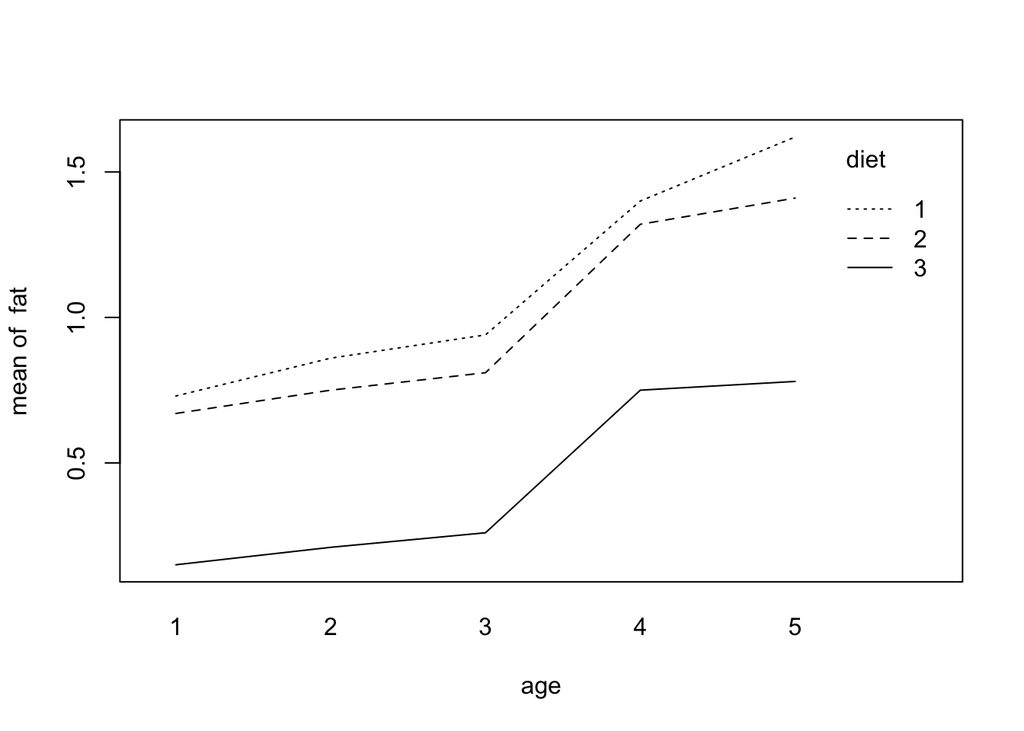

```r
with(aov_fat, interaction.plot(age, diet, fat))
```

The parallell lines in the interaction plot suggest that there are no interactions present between the age and diet factors on the lipid content response.

## 21.7.d

```r
alp = 0.05
df_m = matrix(df$fat, 5,3)
tt = tukey.test(df_m, alpha = alp)
pv = df(tt$stat, 1, 15-5-3)
```

The model under consideration is $Y_{i,j} = \alpha_i + \beta_j + \hat{D}\alpha_i\beta_j + \epsilon_{ij}$. If $\frac{\hat{D}\sum\sum\alpha_i\beta_j}{\frac{SSR}{ab-a-b}} > F^{*}$ where $F^{*} = F_{1,ab-a-b}(1-\frac{0.05}{2})$, then we reject the null hypothesis that there is a non-zero Tukey-type additive interaction between diet and age. The P-value is $0.0111415 <0.05$ so we reject the additive (null) hypothesis.